# Elemental Analysis of September 2013 Murrumbidgee River Water at 6 sites & 4 Tribs

## Elements as they Vary Between Sites

Elements as they vary with Location. The Murrumbidgee sites are the 6 on the left and in descending order. The remaining 4 on the right hand side of the graphs are the 4 tributaries. Gudgenby River, Tuggeranong Creek, Cotter River and the Molongolo River. These are also in descending order.

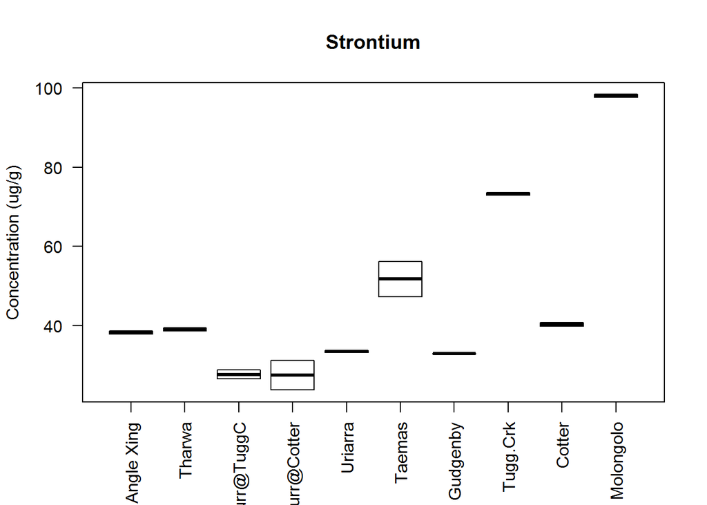

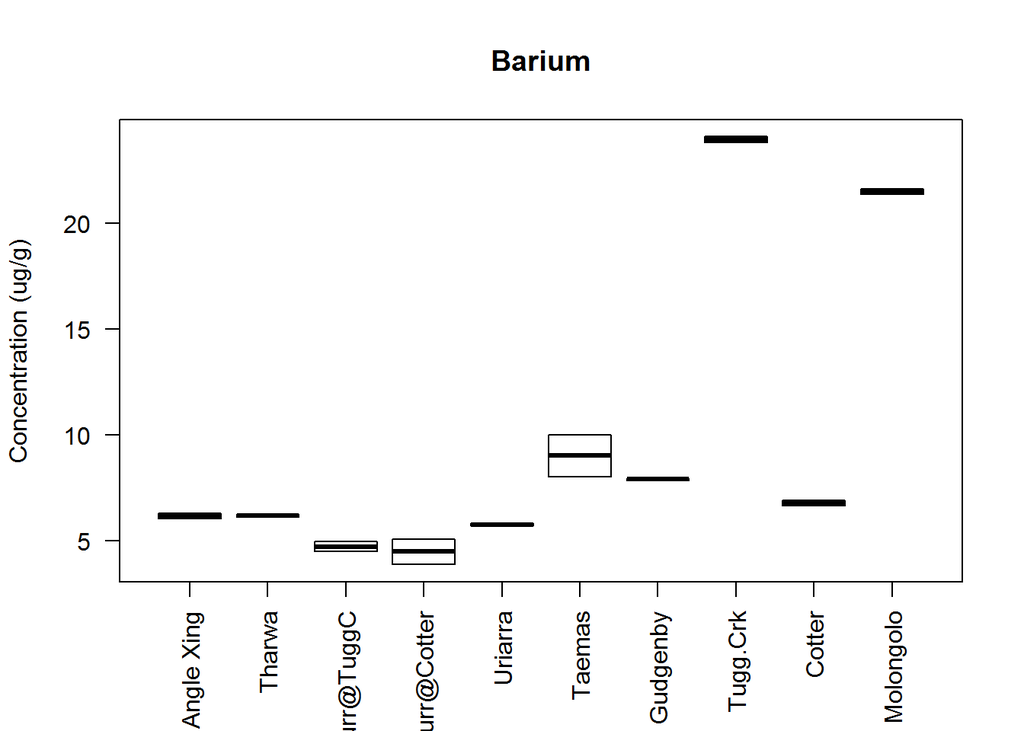

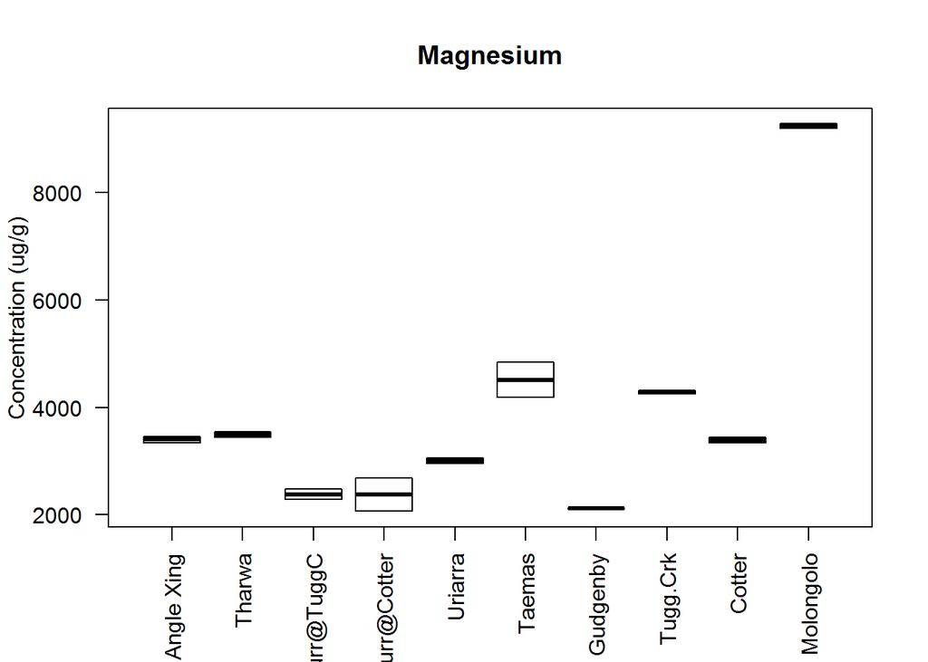

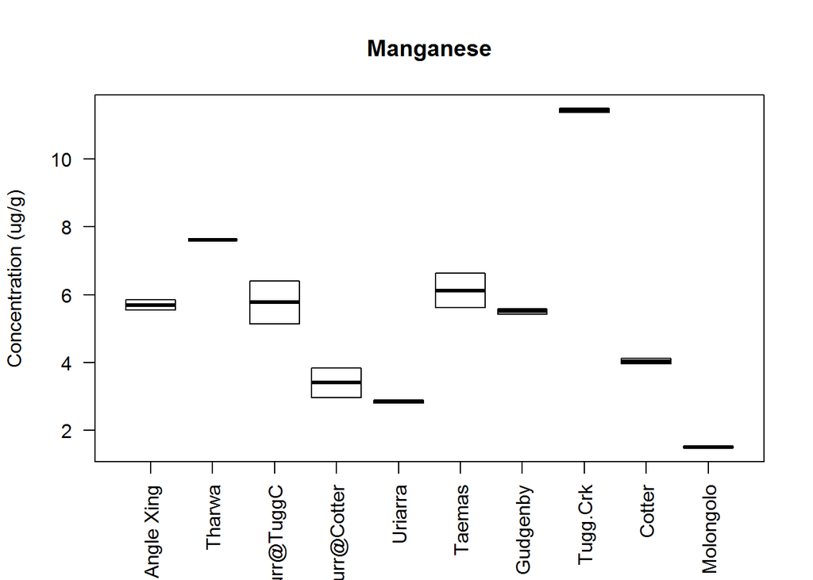

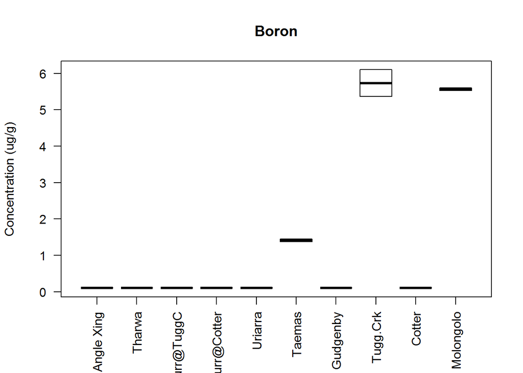

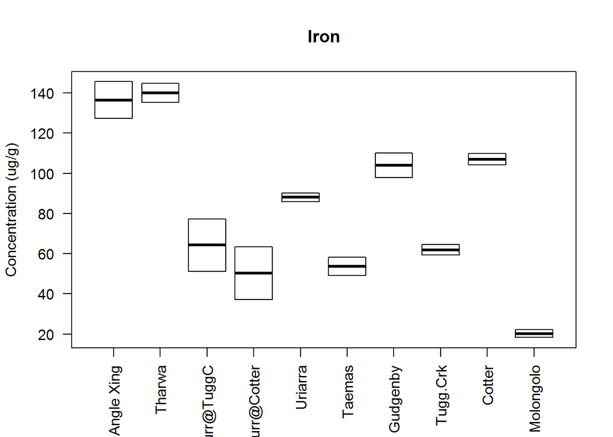

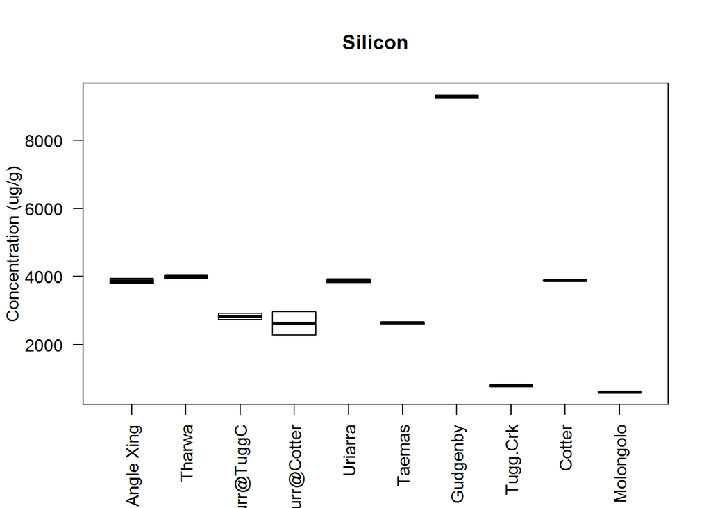

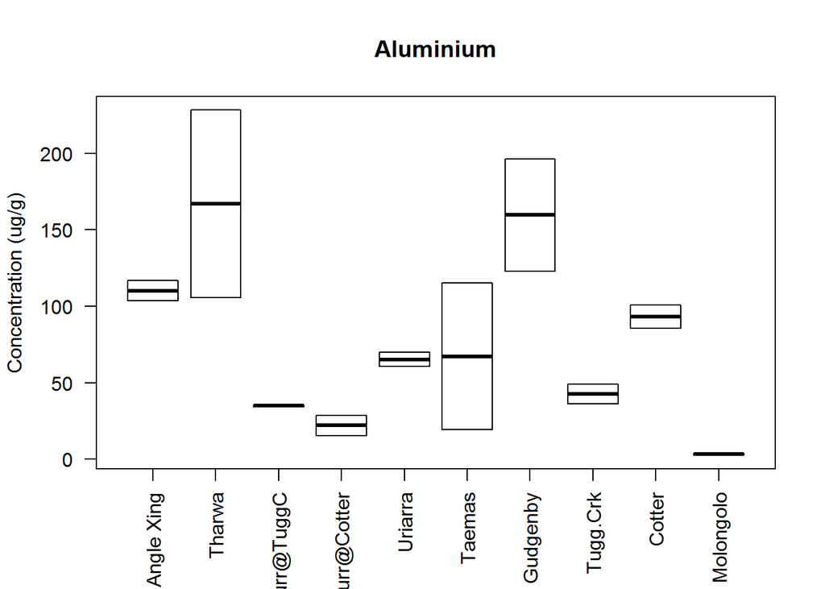

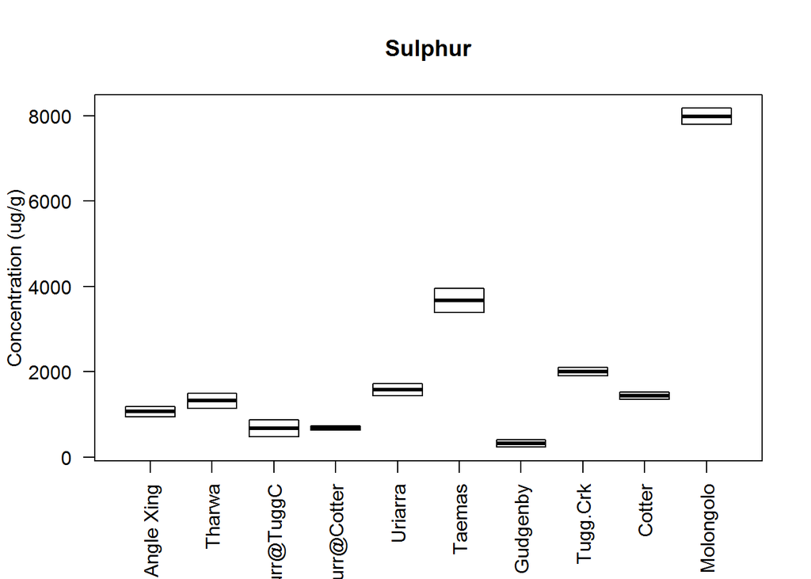

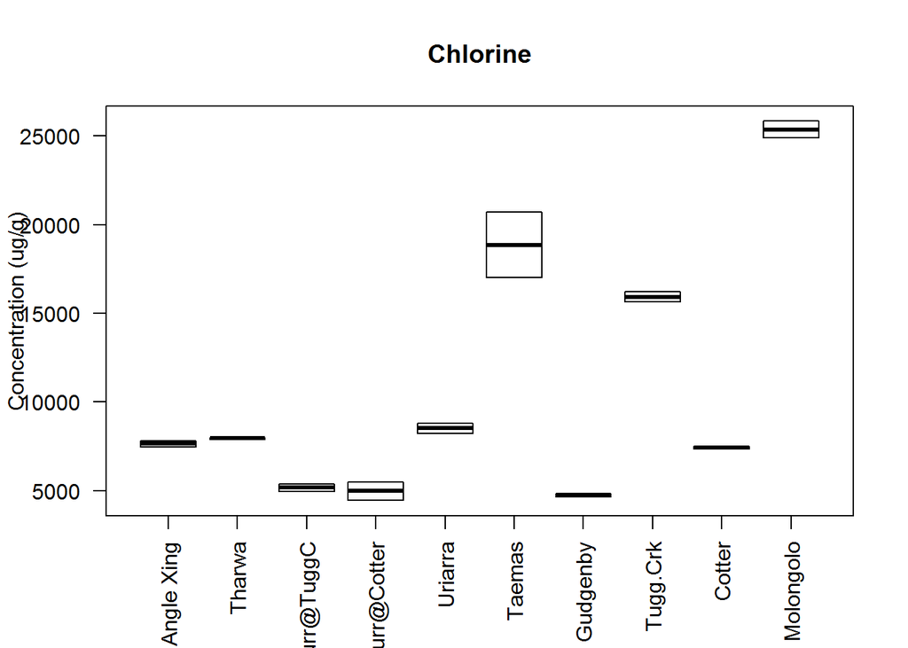

Ratios of the Big Four with Calcium as they Vary Between Sites ————————————————————–

Basic plots of main elements of interest as ratios with Calcium.

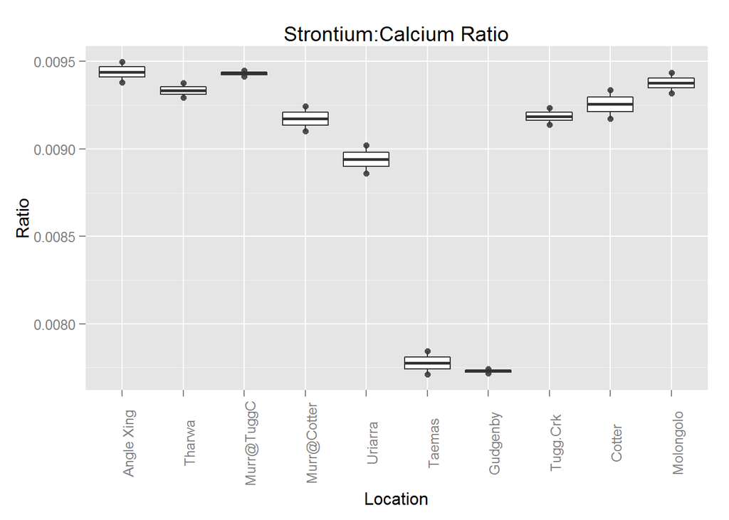

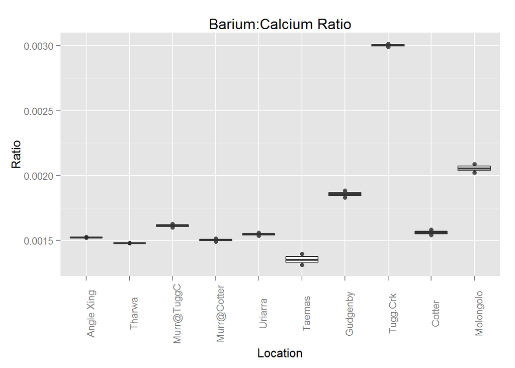

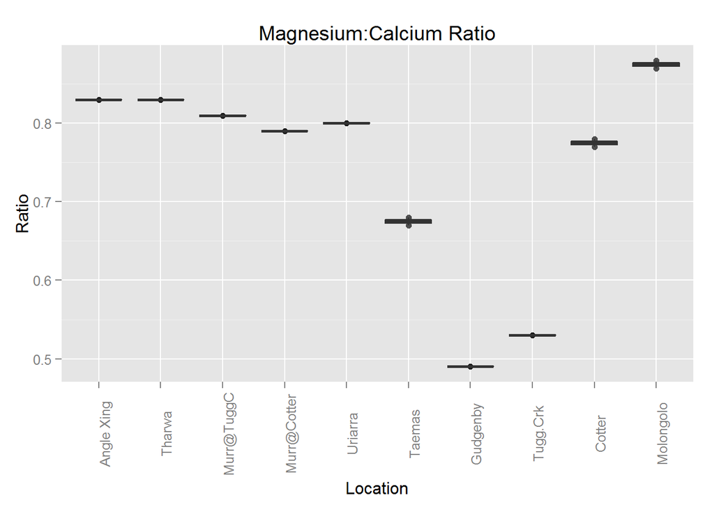

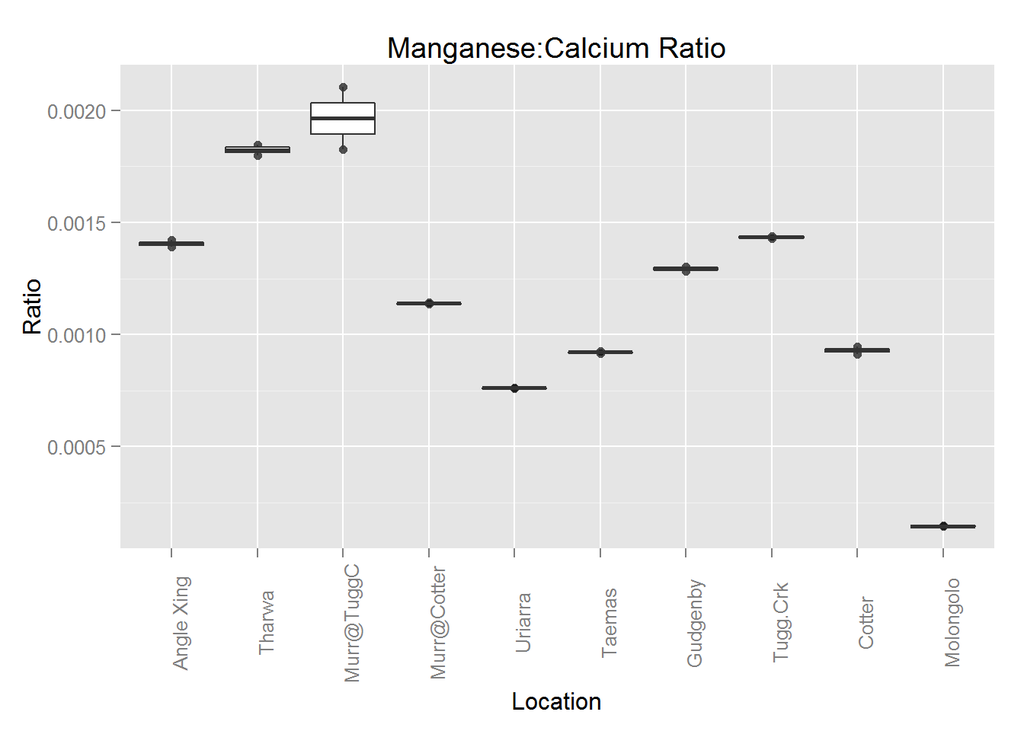

## Correlation Matrix

Plot a simple correlation Matrix to see if there is anything else of interest.

[figure not shown]

## Clusters - Levels and then Ratios

Are clusters evident based on the levels of the four elements (sr,Ba, Mg,Mn) in the water at each site even during this period of moderate flow?

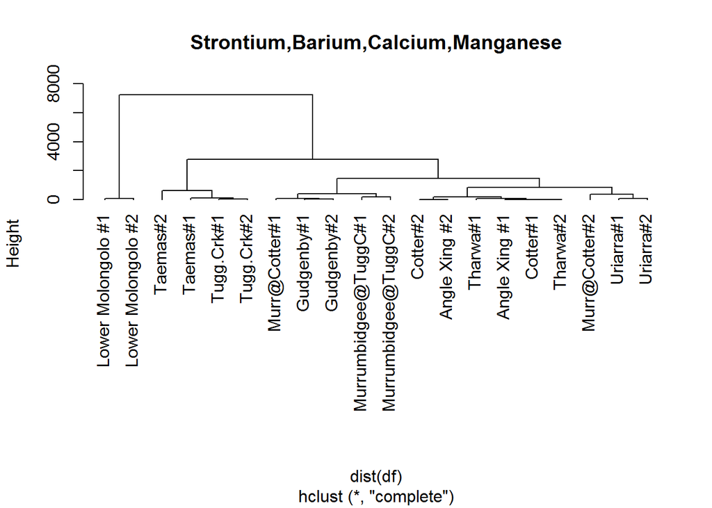

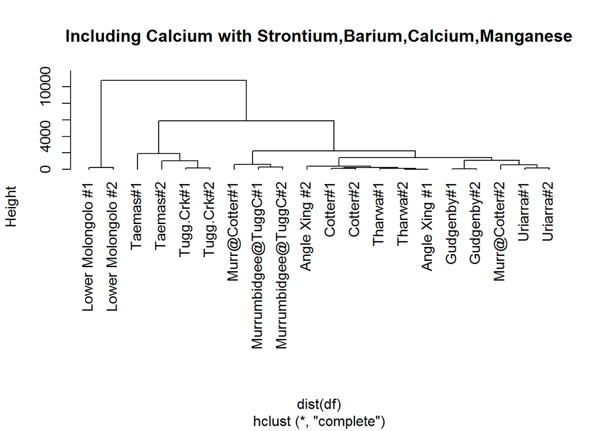

## What if we include more elements?

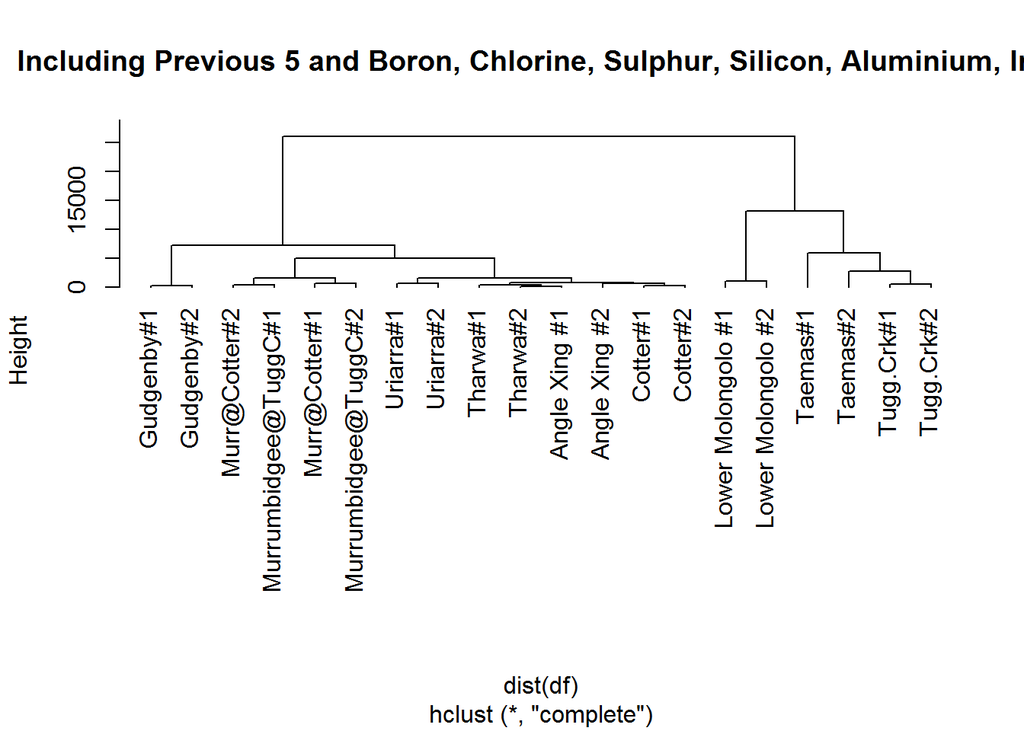

Are clusters evident based on the ratio of these four elements with Calcium?

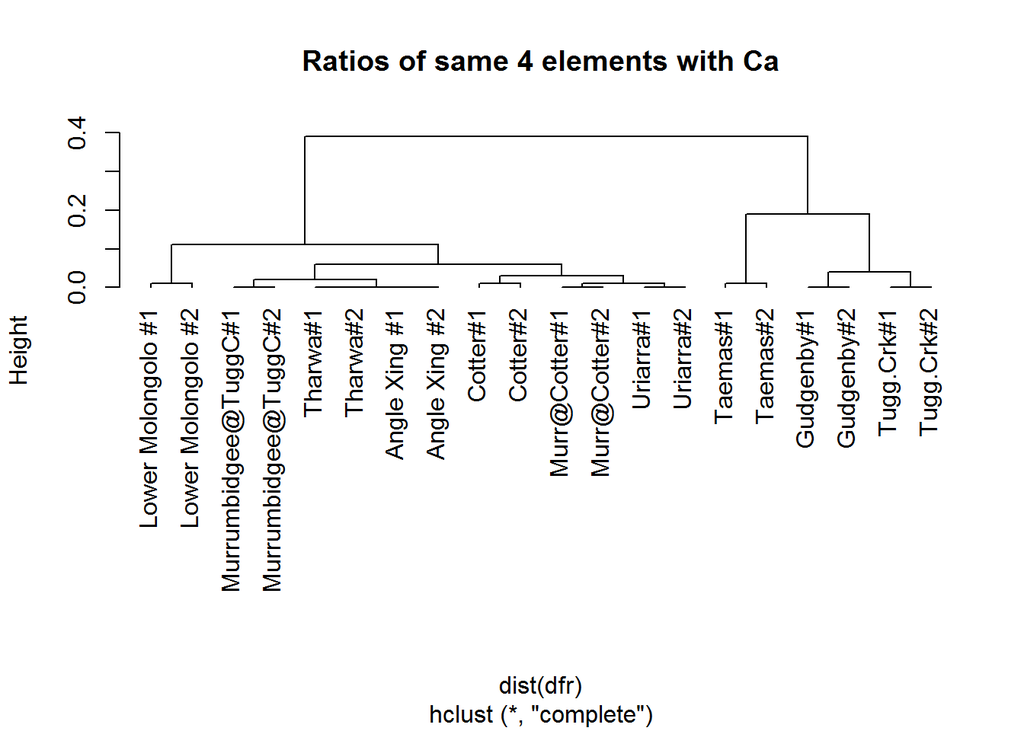

## Table of Original Data

```
##                        LabNo     DateCollected    Location Barium Calcium Strontium Boron Magnesium Manganese   Iron Silicon Aluminium Sulphur Chlorine    Ba.Ca    Sr.Ca Mg.Ca     Mn.Ca
## Tugg.Crk#1           R132333 22/8/2013 0:00:00    Tugg.Crk  24.08    8050     73.56  6.10      4310     11.49  64.49   807.1     49.20  1909.9    16205 0.002992 0.009138  0.53 0.0014279
## Tugg.Crk#2           R132334 22/8/2013 0:00:00    Tugg.Crk  23.81    7896     72.91  5.37      4258     11.37  59.27   771.7     36.19  2099.8    15630 0.003016 0.009235  0.53 0.0014406
## Cotter#1             R132335 23/8/2013 0:00:00      Cotter   6.91    4367     40.78  0.10      3439      4.12 104.25  3892.1     85.59  1527.1     7505 0.001584 0.009338  0.78 0.0009454
## Cotter#2             R132336 23/8/2013 0:00:00      Cotter   6.68    4336     39.77  0.10      3341      3.96 109.79  3874.1    100.72  1360.4     7334 0.001542 0.009173  0.77 0.0009140
## Gudgenby#1           R132337 22/8/2013 0:00:00    Gudgenby   7.86    4293     33.12  0.10      2139      5.59  97.78  9340.2    122.95   411.5     4823 0.001833 0.007716  0.49 0.0013032
## Gudgenby#2           R132338 22/8/2013 0:00:00    Gudgenby   7.97    4235     32.78  0.10      2108      5.43 110.21  9246.2    196.42   238.4     4659 0.001884 0.007741  0.49 0.0012827
## Tharwa#1             R132339 22/8/2013 0:00:00      Tharwa   6.26    4237     39.37  0.10      3541      7.62 144.87  4048.7    228.21  1497.0     7978 0.001480 0.009293  0.83 0.0017997
## Tharwa#2             R132340 22/8/2013 0:00:00      Tharwa   6.11    4128     38.70  0.10      3441      7.62 135.21  3945.8    105.74  1149.3     7899 0.001481 0.009376  0.83 0.0018467
## Angle Xing #1        R132341 23/8/2013 0:00:00  Angle Xing   6.29    4122     38.66  0.10      3462      5.85 145.60  3942.1    116.82  1182.4     7802 0.001527 0.009381  0.83 0.0014207
## Angle Xing #2        R132342 23/8/2013 0:00:00  Angle Xing   6.06    3986     37.86  0.10      3342      5.54 127.35  3804.2    103.46   951.9     7466 0.001521 0.009498  0.83 0.0013906
## Taemas#1             R132343 22/8/2013 0:00:00      Taemas   8.03    6124     47.21  1.37      4190      5.61  49.20  2663.6    115.17  3959.3    20711 0.001312 0.007710  0.68 0.0009173
## Taemas#2             R132344 22/8/2013 0:00:00      Taemas  10.02    7170     56.23  1.45      4837      6.63  58.12  2610.6     19.24  3392.5    16998 0.001398 0.007843  0.67 0.0009248
## Lower Molongolo #1   R132345 22/8/2013 0:00:00   Molongolo  21.36   10553     98.34  5.53      9281      1.54  18.30   599.3      2.88  8170.8    25829 0.002025 0.009319  0.87 0.0001462
## Lower Molongolo #2   R132346 22/8/2013 0:00:00   Molongolo  21.62   10347     97.61  5.60      9202      1.48  22.12   593.3      3.87  7792.9    24874 0.002090 0.009435  0.88 0.0001432
## Uriarra#1            R132347 22/8/2013 0:00:00     Uriarra   5.83    3800     33.66  0.10      3053      2.89  90.15  3926.5     60.56  1724.2     8801 0.001536 0.008861  0.80 0.0007609
## Uriarra#2            R132348 22/8/2013 0:00:00     Uriarra   5.73    3681     33.20  0.10      2956      2.80  85.90  3822.4     69.96  1443.5     8227 0.001559 0.009021  0.80 0.0007617
## Murr@Cotter#1        R132349 22/8/2013 0:00:00 Murr@Cotter   3.89    2609     23.74  0.10      2067      2.96  37.17  2278.1     15.41   631.9     4449 0.001491 0.009101  0.79 0.0011369
## Murr@Cotter#2        R132350 22/8/2013 0:00:00 Murr@Cotter   5.10    3370     31.15  0.10      2690      3.84  63.48  2966.6     28.66   737.8     5498 0.001515 0.009245  0.79 0.0011417
## Murrumbidgee@TuggC#1 R132351 22/8/2013 0:00:00  Murr@TuggC   4.96    3049     28.81  0.10      2474      6.41  77.17  2918.1     35.46   883.0     5362 0.001630 0.009450  0.81 0.0021052
## Murrumbidgee@TuggC#2 R132352 22/8/2013 0:00:00  Murr@TuggC   4.51    2815     26.50  0.10      2286      5.13  51.30  2725.3     34.27   486.2     4965 0.001602 0.009414  0.81 0.0018254
```

The ‘r’ code chunks that are in this document are:

```
##  [1] "Set Global Options"                 "Basic Histograms"                   "Plots of Main Five"                 "Some Ratio Plots"                   "Correlation Matrix)"
##  [6] "clustering of various measures"     "More Elements"                      "Clustering of Ratios"               "Print Original Data to Share"       "Include Labels for all code Chunks"
```